# Week 3-1. Estimate of population proportion

< Back to Syllabus

### 1. Review binomial random variable

- If $Y$ = number of success in $n$ independent trials, then $Y$ is a *binomial random variable* with $\pi$ = probability of success.
  - $Y~B(n, \pi)$
  - PMF of $Y$:

$$p_{Y}(y)=\sum_{n=0}^{n}\left(\begin{array}{l}n \\ k\end{array}\right) \pi(1-\pi) \quad y=0,1, \ldots, n$$

- - Expected value of $Y$, $E(Y)$ is determined by

$$p_{Y}(y)=\sum_{n=0}^{n} y \times\left(\begin{array}{l}n \\ k\end{array}\right) \pi(1-\pi)=n \pi$$

### 2. Sample Proportion

- The **sample proportion** is a random variable and can be defined as:

$$E(P)=E\left(\frac{Y}{n}\right)=\frac{E(Y)}{n}=\frac{n \pi}{n}=\pi$$

- This is an example of the **method of moments**.

> **Method of Moments**

> a way of estimating parameters, based on matching a moment of the data-generating distribution with the related moment of the empirical distribution

#### 2.1 The Maximum Likelihood Estimator (MLE)

- **Maximum likelihood estimator (MLE)** is the quantity that maximizes the **likelihood function**.

#### 2.2 The Likelihood Function

- The **likelihood function** is the probability mass function (PMF) or density (PDF) evaluated at the data $X_1,...,X_n$, views as a **function of the parameter**.
  - Assume we have a set of discrete independent and identically distributed (i.i.d.) random variable’s, $X_1,...,X_n$ whose distribution depends on a parameter $\theta$.
  - Denote the PMF of each $X_i$ as $p(x \mid \theta)$
- - the likelihood is then

$$L(\theta)=\prod_{i=1}^{n} p\left(x_{i} \mid \theta\right)$$

- But it is often more useful to compute the log-likelihood function:

$$l(\theta)=\sum_{i=1}^{n} \log p\left(x_{i} \mid \theta\right)$$

- View the above as a **function of the parameter**.
  - Thus, it is important to **define the parameter space** or **the set of values that a parameter can take**.

#### 2.3 Example: Likelihood of a Binomial Sample

Suppose that we want to test whether a coin is fair, i.e., if the probabilities that it lands on “heads” or “tails” are the same. We can flip the coin a few times, say $n=15$ and see how many times it give “heads” ($x=1$) or “tails” ($x=0$). Then $Y=X_1+...+X_n$ is a **binomial random variable, $Y~B(n, \pi)$.

- More formally, we have a series of i.i.d. Bernoulli random variables (which you can think of as a Binomial with $n=1$), $X_1,...,X_n$, such that

$$X_{i} \sim B(1, \pi)$$

- We don’t know $\pi$ since we don’t know whether the coin is fair, but we know the **observed values of x_i** in that we performed the experiment.
  - We can compute the **likelihood function of the $n$ Bernoulli trials:

$$L(\pi)=\prod_{i=1}^{n} \pi^{x_{i}}(1-\pi)^{1-x_{i}}, \quad x_{i} \in\{0,1\}$$

- And the log-likelihood function is

$$\begin{aligned} l(\pi) &=\sum_{i=1}^{n} x_{i} \log \pi+\left(1-x_{i}\right) \log (1-\pi) \\ &=n {\log }(1-\pi)+(\log \pi-\log (1-\pi)) \sum_{i=1}^{n} x_{i} \end{aligned}$$

- `R`

```r
set.seed(1)
(x <- rbinom(15, size = 1, prob = .5))
```

```
##  [1] 0 0 1 1 0 1 1 1 1 0 0 0 1 0 1
```

```r
loglik <- function(pi, data) {
    sum(log(dbinom(data, size = 1, prob = pi)))
}

loglik(pi = .5, data = x) %>% round(3)
```

```
## [1] -10.397
```

```r
loglik(pi = .4, data = x) %>% round(3)
```

```
## [1] -10.906
```

- Plot the likelihood over a range of $\pi$ values

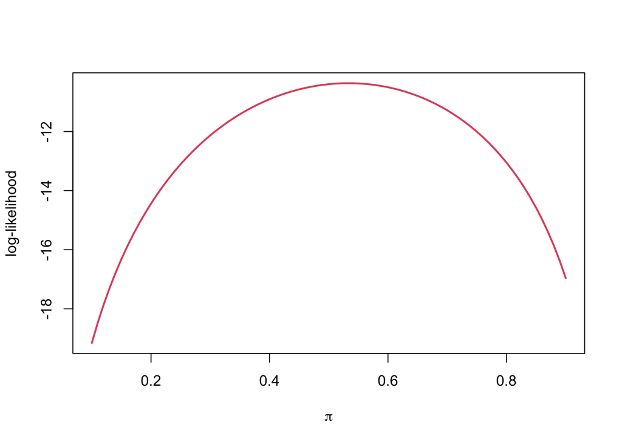

```r
pis <- seq(0.1, 0.9, by = 0.01)
ll <- sapply(pis, loglik, data = x)
plot(pis, ll, type = 'l', col = 2, lwd = 2,
     xlab = expression(pi),
     ylab = 'log-likelihood')
```

- The **maximum likelihood estimator (MLE)** is the parameter value that maximizes the likelihood (or log-likelihood) function.
  - Take the derivative of the log-likelihood function with respect to the parameter, $\theta$.
  - Find the value of the parameter for which the derivative = 0.

$$\begin{aligned} \frac{d l(\pi)}{d \pi}=& \frac{1}{\pi(1-\pi)} \sum_{i=1}^{n} x_{i}-\frac{n}{1-\pi} \\=& \frac{\sum_{i=1}^{n} x_{i}-n \pi}{\pi(1-\pi)} \\=& 0 \\ & \hat{\pi}=\frac{1}{n} \sum_{i=1}^{n} x_{i} \end{aligned}$$

- `R`

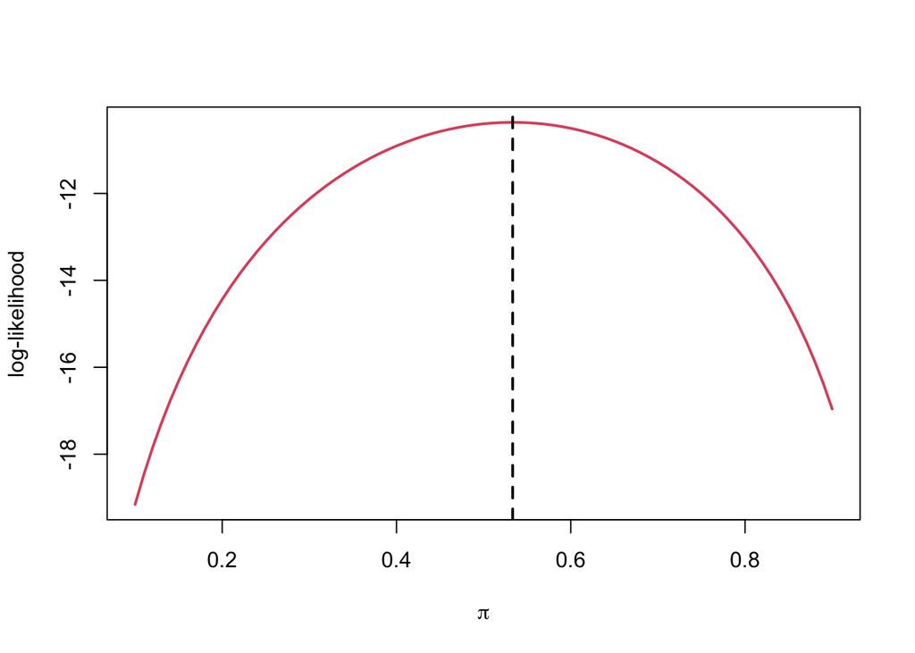

```r
plot(pis, ll, type = 'l', col = 2, lwd = 2,
     xlab = expression(pi),
     ylab = 'log-likelihood')
abline(v = mean(x), lty = 2, lwd = 2)
```

### 3. Properties of the estimators

#### 3.1 Properties of estimators: Bias

- An estimator, $\hat{\theta}$, is a random variable for which we can compute mean and variance.
- Can define the **bias of an estimator** as:

$$\operatorname{Bias}=E[\hat{\theta}]-\theta$$

- An unbiased estimator is when

$$E[\hat{\theta}]=\theta$$

#### 3.2 Mean Squared Error (MSE)

- When we **compare two estimators**, we care both **bias** and **variance**.
- We may prefer a biased estimator over an unbiased one, if the bias estimator has smaller variance.
- **Bias-variance tradeoff**
- A measure to compare two estimators is the **mean squared error (MSE)**, which combines bias and variance.

$$M S E[\hat{\theta}]=E\left[(\hat{\theta}-\theta)^{2}\right]=\operatorname{Var}(\hat{\theta})+\operatorname{Bias}(\hat{\theta})^{2}$$

#### 3.3 Consistency

- An estimator, $\hat{\theta}$, is **consistent**, as $n$ goes to infinity, it converges in probability to the true parameter value $\theta$. For any $\varepsilon>0$.
  - There are two methods.

$$\begin{array}{c}1) \lim _{n \rightarrow \infty} \operatorname{Pr}\left(\left|\hat{\theta}_{n}-\theta\right|>\varepsilon\right)=0 \\ 2) \lim _{n \rightarrow \infty} M S E\left(\hat{\theta}_{n}\right)=0\end{array}$$

#### 3.4 Example: sample proportion

- We know that $E(P)=\pi$, and this is an **unbiased estimator** of $\pi$.
- The **MSE of the sample proportion, P**, can be determined.
- We talked about the $\operatorname{Var}(P)=\frac{\pi(1-\pi)}{n}$

$$M S E(P)=\operatorname{Var}(P)+\operatorname{Bias}(P)^{2}=\frac{\pi(1-\pi)}{n}+0$$

- This implies that **an estimator of the population proportion based on a larger sample size will have a smaller MSE than one based on a samller sample size**.
- To determine whether the sample proportion is a **consistent estimator** we note that as $n$ goes to infinity,

$$M S E\left(P_{n}\right)=\frac{\pi(1-\pi)}{n} \rightarrow 0$$

- Thus, the sample proportion is consistent.

### 4. Why Confidence Intervals?

#### 4.1 Confidence Intervals

- Statistics is not only about estimating the unknown quantities in the population, but also about **estimating the uncertainty of the estimates**.
- Once we have an estimate of our parameter of interest, $\hat{\theta}$, we want to construct a range of plausible values for the true value of $\theta$.
- We want to be confident, say at the 95% level, that the true parameter lies within a certain range (or interval).

> **Quantiles of the sampling distribution**
> - Use the quantiles of the sampling distribution to compute the probability that the parameter lies within the interval.

> $$\operatorname{Pr}\left(q_{0.025} \leq \hat{\theta} \leq q_{0.975}\right)=0.95$$
> - Also we often know the exact or approximate distribution of $\hat{\theta}$. Thus, we can compute the qunatiles to obtain the interval.

#### 4.2 Exact 95% CI for the sample proportion

- $Y~B(n, \pi)$
- Use the quantiles of the sampling distribution of $P$ to compute the confidence interval.

$$\begin{aligned} 0.95 &=\operatorname{Pr}\left(q_{0.025} \leq P \leq q_{0.975}\right) \\ &=\operatorname{Pr}\left(q_{0.025} \leq \frac{Y}{n} \leq q_{0.975}\right) \\ &=\operatorname{Pr}\left(n q_{0.025} \leq Y \leq n q_{0.975}\right) \end{aligned}$$

- `R`: `n*qbinom(0.025, n, $\pi$)` to `n*qbinom(0.975, n, $\pi$)`
- To determine the **lower limit** of the confidence interval, $P_L$ and the **upper limit**, $P_U$ by solving the equations below
- Upper limit:

$$\sum_{k=0}^{y}\left(\begin{array}{l}n \\ k\end{array}\right) p_{U}^{k}\left(1-p_{U}^{n-k}\right)=\frac{0.05}{2}=0.025$$

- Lower limit:

$$\sum_{k=0}^{y-1}\left(\begin{array}{l}n \\ k\end{array}\right) p_{L}^{k}\left(1-p_{L}^{n-k}\right)=1-\frac{0.05}{2}=0.975$$

- The interval ($P_L$, $P_U$) is an exact 100(1-$\alpha$)% CI for $P$.
  - $\alpha$ = 0.05
  - $y$ = observed number of successes
  - $n$ = number of trials
  - $f_u$ = $F(y, p_u, n) - \alpha/2$
  - $f_1$ = $F(y-1, p_l, n) - (1-\alpha/2)$

> F is the cumulative density function (CDF) for the binomial distribution.
- Find the value of $p_u$ that corresponds to $f_u=0$ and the value of $p_l$ that corresponds to $f_l=0$ using `R`.

```r
ciLimits <- function(y, n, alpha) {
    fl <- function(p) {
        pbinom(y - 1, n, p) - (1 - alpha/2)
    }
    fu <- function(p) {
        pbinom(y, n, p) - alpha/2
    }
    pl <- uniroot(fl, c(0.01, 0.99))
    pu <- uniroot(fu, c(0.01, 0.99))
    return(c(pl$root, pu$root))
}
```

#### 4.3 Example: Number of heads in 15 coin flips

Suppose we are interested in determining whether a coin is fair and we flip it 15 times. We observe that there were 4 heads observed. + Point Estimate: $p=y/n=4/15=0.267$ + CI:

```r
ciLimits(y = 4, n = 15, alpha = 0.10) %>% round(3)
```

```
## [1] 0.097 0.511
```

- Conclusion: The 90% confidence interval is 0.097, 0.511. Since the interval contains 0.5, the results are consistent with a fair coin.
- `R binom.test(y, n)`
  - $y$ = observed number of successes
  - $n$ = number of trials.

```r
binom.test(x = 4, n = 15, conf.level = 0.90)
```

```
##
##  Exact binomial test
##
## data:  4 and 15
## number of successes = 4, number of trials = 15, p-value = 0.1185
## alternative hypothesis: true probability of success is not equal to 0.5
## 90 percent confidence interval:
##  0.09665833 0.51075189
## sample estimates:
## probability of success
##              0.2666667
```

#### 4.4 Interpretation of Confidence Interval

- Be careful in interpreting the result.
- $\pi$ is a parameter, not a random variable
- The randomness comes from $P$, the sample proportion, which means that the **boundaries of the interval are random**.
  - Correct: there is a 95% chance the interval contains $\pi$
  - Incorrect: there is a 95% chance that $\pi$ is in the interval.
    - This is incorrect because the population proportion is a parameter, not a random variable. The value of the population proportion does not vary from sample to sample. Only $P$ and the **CI** varies from sample to sample.

#### 4.5 One-sided Confidence Interval

- There are two types of intervals: one-sided and two-sided.
  - Two-sided intervals have both a lower and upper bound. It usually assigns half the $\alpha$ value to the lower side and half the $\alpha$ to the upper side.
  - One-sided intervals is used when we are only interested in either the lower or the upper bound. In this case, all of $\alpha$ goes to one-side.
- e.g. Suppose we wanted to know whether a coin was biased so that the probability of heads is greater than 0.50. As before, we flip the coin 15 times and observe 4 heads. In this case, we would be interested in having a lower bound for our confidence interval so we can see if the lower bound is greater than 0.50.

```r
binom.test(4,15,conf.level=0.90, alternative="greater")
```

```
##
##  Exact binomial test
##
## data:  4 and 15
## number of successes = 4, number of trials = 15, p-value = 0.9824
## alternative hypothesis: true probability of success is greater than 0.5
## 90 percent confidence interval:
##  0.1217687 1.0000000
## sample estimates:
## probability of success
##              0.2666667
```

- - Conclusion: We can see that this interval contains 0.50 and this is consistent with the coin being fair; there is no evidence that the probability of heads is greater than 0.50.
- e.g. Suppose we wanted to know whether a coin was biased so that the probability of heads is less than 0.50. As before, we flip the coin 15 times and observe 4 heads. In this case, we would be interested in having an upper bound for our confidence interval so we can see if the upper bound is less than 0.50.

```r
binom.test(4,15,conf.level=0.90, alternative="less")
```

```
##
##  Exact binomial test
##
## data:  4 and 15
## number of successes = 4, number of trials = 15, p-value = 0.05923
## alternative hypothesis: true probability of success is less than 0.5
## 90 percent confidence interval:
##  0.0000000 0.4639709
## sample estimates:
## probability of success
##              0.2666667
```

- - Conclusion: We can see that this interval does NOT contains 0.50 and this is inconsistent with the coin being fair; there is evidence that the probability of heads is less than 0.50.

### 5. Normal distribution approximation of a binomial distribution

- When $n$, $n \pi$, and $n(1-\pi)$ are sufficiently large, then the binomial distribution is well approximated by the normal distribution.

$$B(n, \pi) \sim N(n \pi, \sqrt{n \pi(1-\pi)})$$

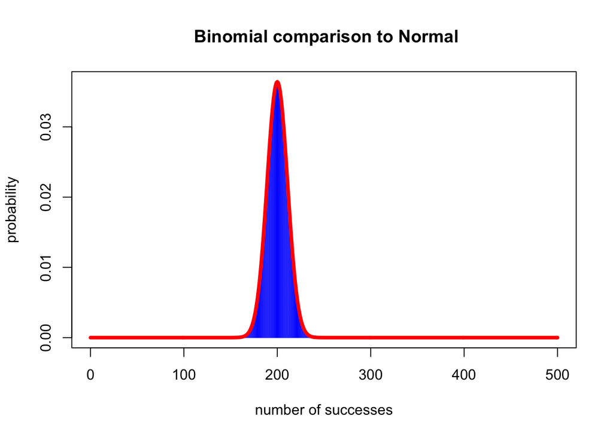

```r
plot(0:500, dbinom(0:500, 500, 0.4),
     type = "h",
     col = "blue",
     xlab = "number of successes",
     ylab = "probability",
     main = " Binomial comparison to Normal")
lines(0:500, dnorm(0:500, 200, sqrt(500 * 0.4 * 0.6)), lwd = 4, col = "red")
```

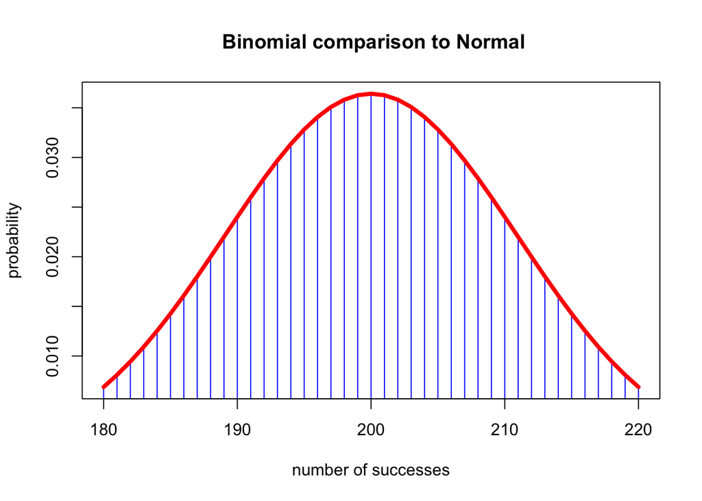

```r
plot(180:220, dbinom(180:220, 500, 0.4), type = "h", col = "blue", xlab = "number of successes",
    ylab = "probability", main = " Binomial comparison to Normal")
lines(180:220, dnorm(180:220, 200, sqrt(500 * 0.4 * 0.6)), lwd = 4, col = "red")
```

- The closer $\pi$ is to 0.5, the better the normal approximation will be.
  - If $n \le 50$, the approximation will not be good
  - Rule of thumb: $n \pi(1-\pi) \ge 10$

#### 5.1 Implications for the confidence interval for the sampling propotion

- If $n \pi(1-\pi) \ge 10$ (i.e., sufficiently large), the sampling distribution for the sample proportion can be approximated by a normal distribution with mean $\pi$ and standard deviation of $\sqrt{(\pi(1-\pi) / n)}$.
- So for large $n$ (i.e., $n \pi(1-\pi) \ge 10$), an approximate 100(1-$\alpha$)% confidence interval for $\pi$, can be determined with a normal distribution.

#### 5.2 Example: Approximation of 95% Confidence Interval for the population proportion

$$0.95=\operatorname{Pr}\left(q_{0.025} \leq \frac{p-\pi}{\sqrt{p(1-p) / n}} \leq q_{0.975}\right)$$

- The quantity given above has a standard normal distribution.
- `R`

```r
qnorm(0.025)
```

```
## [1] -1.959964
```

```r
qnorm(0.975)
```

```
## [1] 1.959964
```

$$0.95=\operatorname{Pr}\left(p-q_{0.975} \sqrt{p(1-p) / n} \leq \pi \leq p+q_{0.975} \sqrt{p(1-p) / n}\right)$$

$$0.95=\operatorname{Pr}(p-1.96 \sqrt{p(1-p) / n} \leq \pi \leq p+1.96 \sqrt{p(1-p) / n})$$

- e.g. Suppose we have a random sample of 500 individuals from a population and that 212 of them are obese (e.g. have a BMI > 30).
- <1> What is an estimate for the proportion of obese individuals in this population?

```r
binom.test(212, 500, conf.level = 0.90)
```

```
##
##  Exact binomial test
##
## data:  212 and 500
## number of successes = 212, number of trials = 500, p-value = 0.0007798
## alternative hypothesis: true probability of success is not equal to 0.5
## 90 percent confidence interval:
##  0.3870533 0.4616173
## sample estimates:
## probability of success
##                  0.424
```

- <2> What is the 90% confidence interval obtained from a normal approximation?

```r
(lower <- 0.424 - 1.645 * sqrt(0.424 * 0.576 / 500)) %>% round(3)
```

```
## [1] 0.388
```

```r
(upper <- 0.424 + 1.645 * sqrt(0.424 * 0.576 / 500)) %>% round(3)
```

```
## [1] 0.46
```

```r
(test <- prop.test(212, 500, conf.level = 0.90))
```

```
##
##  1-sample proportions test with continuity correction
##
## data:  212 out of 500, null probability 0.5
## X-squared = 11.25, df = 1, p-value = 0.0007962
## alternative hypothesis: true p is not equal to 0.5
## 90 percent confidence interval:
##  0.3871687 0.4616718
## sample estimates:
##     p
## 0.424
```

- Using the `prop.test()` the 90% CI is 0.387, 0.462.

> `R` function gives more accurate estimates is that it uses a **correction for continuity**. Specifically the binomial distribution is discrete and the normal distribution is continuous so a correction is needed to assign the area under the curve (AUC) to each mass of the binomial.

< Back to Syllabus